# 2018-02-12 pNF Drug Screening tSNE Target Clusters

Robert Allaway

2/12/2019

## Prepare the drug-target dataset.

We’ve already done the hard work of mapping IDs in these two datasets together, so we just need to filter down to get a list of targets. We’ll assume everything with a pChEMBL >6 is a “real” target.

```r
targets <- syn$get("syn17091507")$path %>% readRDS() %>%
  filter(mean_pchembl > 6) %>%
  select(internal_id, hugo_gene, std_name) %>%
  distinct()
```

## Prepare the drug screening data.

This data is standardized across all public NF studies, and a variety of drug metrics were calculated each experiment. However, there is a *lot* of diverse data here, so we should do a bit to clean up the data and narrow the scope, and eliminate metrics that might not be that accurate.

Specificially, we will:

-get the dataset

-filter for NF1 deficient pNF cell lines

-remove outlier cell line ‘ipNF95.11b C’

-filter out the combination data (too complicated for a first pass of this method)

-select only the information we need

-`inner_join` on the target dataset to filter out any drugs that we don’t have target info for.

- binarize the target dataset after it has been reduced to only the drugs we can evaluate

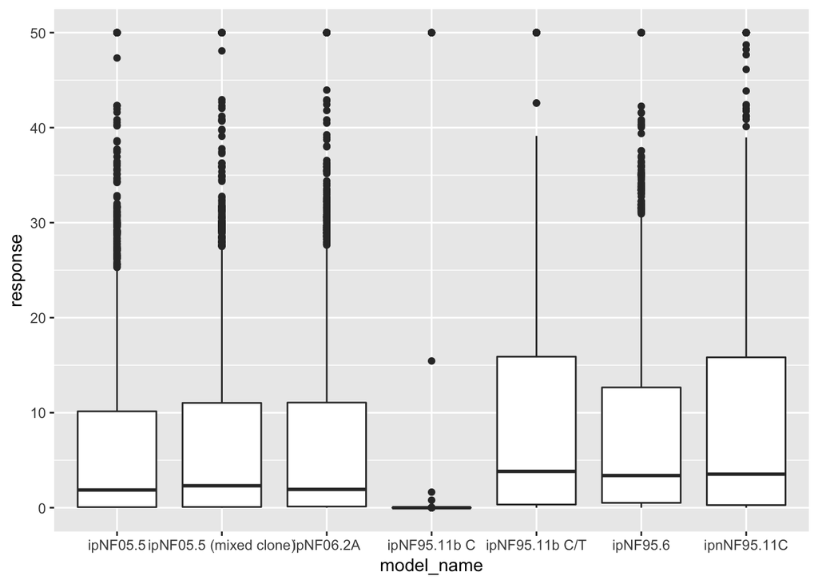

```r
drug_data <- syn$get("syn17462699")$path %>% read.csv()

pnf <- c("ipNF05.5", "ipNF06.2A", "ipNF95.11b C/T", "ipnNF95.11C", "ipNF95.6", "ipNF05.5 (mixed clone)", "ipNF95.11b C")

drug_data_filt_1 <- drug_data %>%
  filter(response_type == "IC50_rel") %>%
  filter(model_name %in% pnf) %>%
  group_by(drug_screen_id) %>%
  filter(n() == 1) %>%
  ungroup() %>%
  mutate(response = case_when(response < 50 ~ response,
                              response >= 50 ~ 50))

ggplot(data = drug_data_filt_1) +
  geom_boxplot(aes(x = model_name, y = response))
```

```r
drug_data_filt <- drug_data_filt_1 %>%
  filter(model_name != "ipNF95.11b C") %>%
  group_by(DT_explorer_internal_id) %>%
  filter(n() > 3) %>%
  ungroup() %>%
  select(DT_explorer_internal_id, response) %>%
  group_by(DT_explorer_internal_id) %>%
  summarize('median_response' = median(response))%>%
  ungroup()


target_data_filt <- drug_data_filt %>%
  inner_join(targets, by = c("DT_explorer_internal_id" = "internal_id")) %>%
  select(DT_explorer_internal_id, hugo_gene) %>%
  distinct() %>%
  add_column(foo = c(1)) %>%
  spread(hugo_gene, foo, fill = 0) %>%
  column_to_rownames("DT_explorer_internal_id") %>%
  as.matrix()
```

Then, we take the binarized target matrix (`target_data_filt`) and use UMAP (`umap`) to reduce the dimensionality of the matrix. This allows us to visualize the grouping.

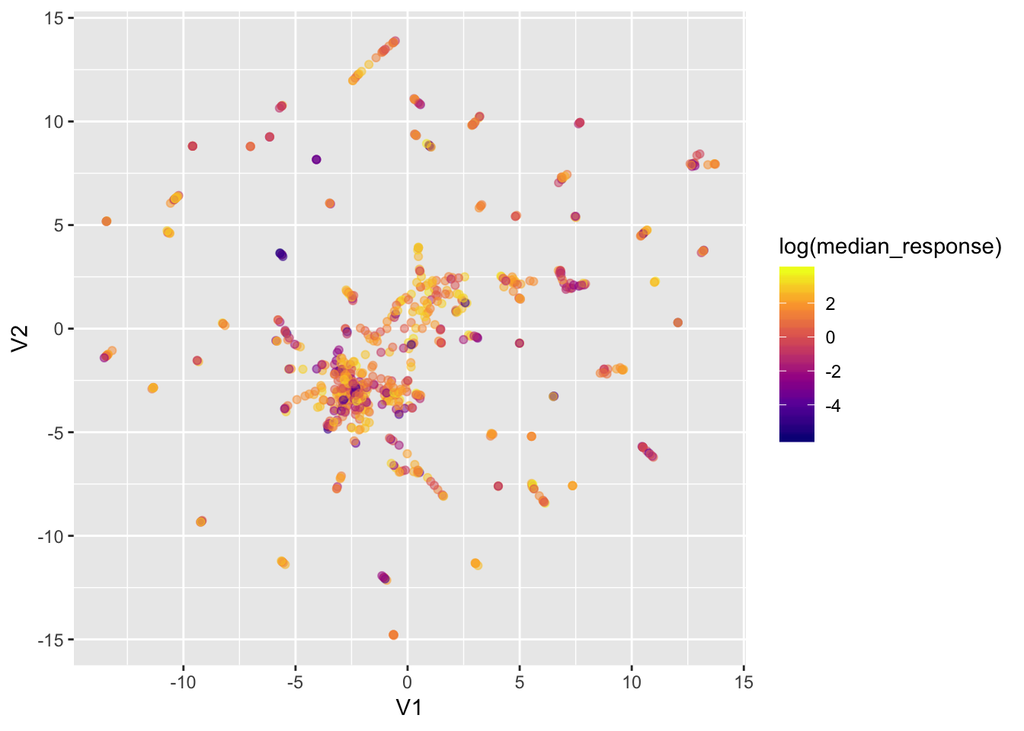

```r
foo <- umap(target_data_filt,
            method = "umap-learn",
            epochs = 500,
            n_neighbors = 3,
            metric = "euclidean",
            random.state = 90210)

foo2 <- foo$layout %>% as.data.frame() %>% add_column("DT_explorer_internal_id" = as.integer(rownames(target_data_filt))) %>% left_join(drug_data_filt) %>% left_join(distinct(select(targets, internal_id, std_name)), by = c("DT_explorer_internal_id" = "internal_id"))

ggplot(foo2) + geom_point(aes(x = V1, y = V2, color = log(median_response)), alpha = 0.5) + scale_color_viridis_c(option = "C")
```

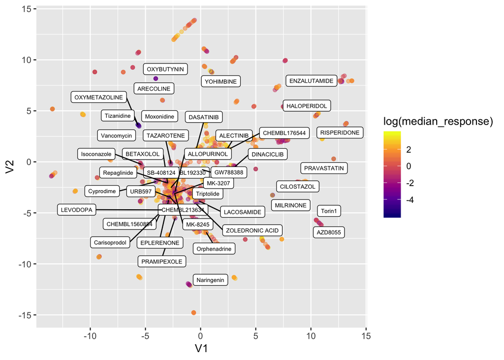

```r
ggplot(foo2) + geom_point(aes(x = V1, y = V2, color = log(median_response)), alpha = 0.5) +
  scale_color_viridis_c(option = "C")  +
  ggrepel::geom_label_repel(data = foo2 %>% filter(median_response < 0.05), aes(x = V1, y = V2, label = std_name), size = 2)
```

So this is nice, but what if we want to identify clusters of drugs with a low median IC50? Well, we can use `umap` to reduce the dimensionality of the drug-target data, and then cluster these reduced dimensions using a method like HDBSCAN. So let’s do that. I’ve taken the suggestion of the umap-learn documentation and doubled the number of nearest neighbors from before, (3 to 6) and reduced the minimum distance to 0. I’ve also moved from 2 components for nicer visualization, to 3 for some more separation. I tried several numbers of components between 3 and 50, and found that anything above three resulted in too many small clusters to be useful.

```r
foo <- umap(target_data_filt,
            method = "umap-learn",
            epochs = 500,
            n_neighbors=6,
            min_dist=0.0,
            n_components=3,
            metric = "euclidean",
            random.state = 90210
)
clusters <- hdbscan(foo$layout, minPts = 3)

foo2 <- foo$layout %>%
  as.data.frame() %>%
  add_column("DT_explorer_internal_id" = as.integer(rownames(target_data_filt))) %>%
  add_column("cluster" = clusters$cluster) %>%
  left_join(drug_data_filt_1) %>%
  group_by(cluster) %>%
  mutate('median_response' = median(response))%>%
  ungroup() %>%
  filter(cluster != 0) %>%
  left_join(distinct(select(targets, internal_id, std_name)), by = c("DT_explorer_internal_id" = "internal_id"))

##this is to look at targets by cluster
#clustarg <- inner_join(foo2, targets) %>% select(cluster, DT_explorer_internal_id, std_name, hugo_gene) %>% distinct()
```

That gives us to this clustering in components 1, 2 and 3 (color is component 3):

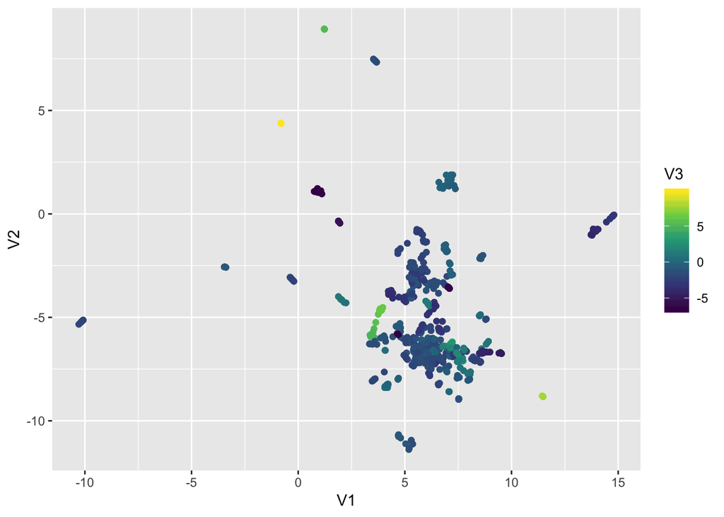

```r
ggplot(foo2) +
  geom_point(aes(x = V1, y = V2, color = V3), alpha = 0.5) +
  scale_color_viridis_c(option = "D")
```

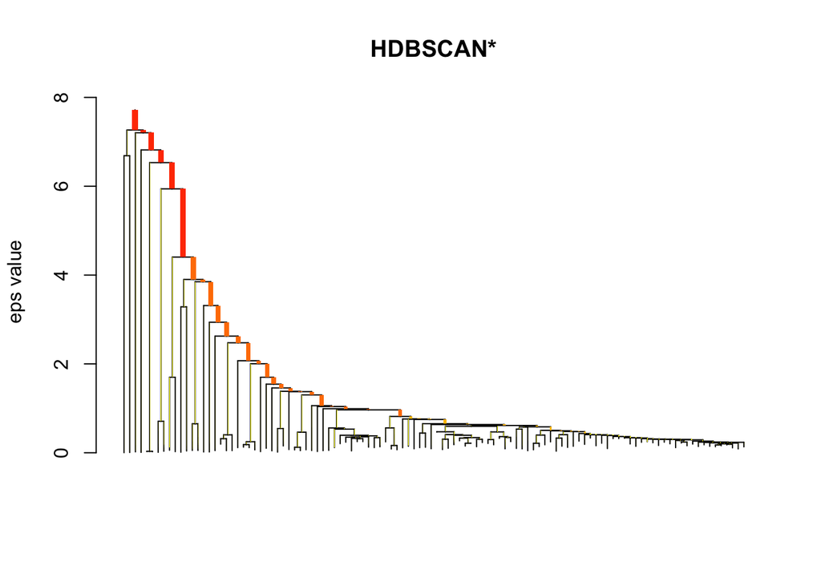

```r
plot(clusters)
```

We can also color the individual clusters as defined by HDBCLUST. There are lots of very close clusters, so this isn’t the most straightforward visualization, but you can get a general sense that the color of the cluster maps closely to the magnitude of the components for each point - i.e. clusters are spatially visible.

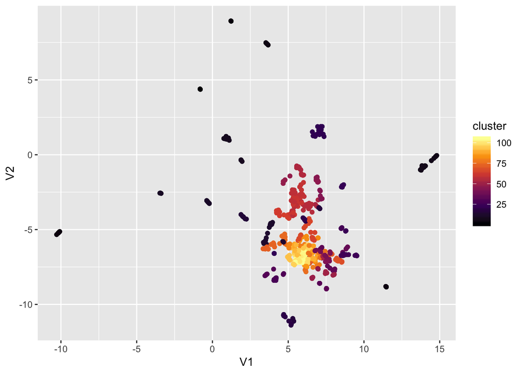

```r
ggplot(foo2) +
  geom_point(aes(x = V1, y = V2, color = cluster), alpha = 0.5) +
  scale_color_viridis_c(option = "B")
```

Finally, we can select for only the best clusters and plot some labels see what drugs are in them Here, I’m filtering only for clusters that have a median IC50 < 250 nM across all cell lines and drugs for that cluster. An important note - this is the *median IC50* for each cluster, so some of these drugs may have had no effect, and that could be masked by the overall cluster average.

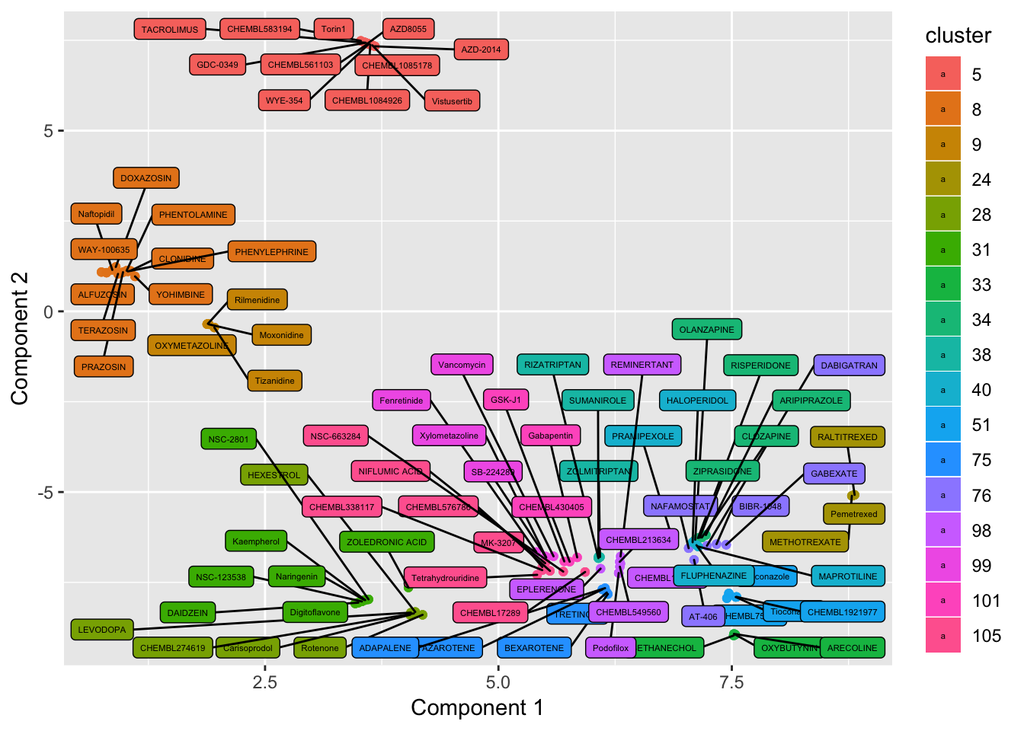

```r
foo3 <- foo2 %>% filter(median_response < 0.25) %>% mutate(cluster = as.factor(cluster))

ggplot(foo3) +
  geom_point(aes(x = V1, y = V2, color = cluster), alpha = 0.5) +
  ggrepel::geom_label_repel(data = foo3 %>%
                              select(V1,V2,std_name, cluster) %>%
                              distinct(), aes(x = V1, y=V2, label = std_name, fill = cluster), size = 1.5)+
  labs(x = 'Component 1', y = "Component 2")
```

This is a good start as a proof of concept, but I think we’d need to test the parameters in both `umap-learn` and `HDBSCAN` a bit more systematically to see how stable these findings are. One future possibility is using `umap` to see what other compounds might fall into these clusters, even though we don’t have IC50 data for them.